# Dynamic local labor-market effects of the 2025 U.S. tariffs

Exposure construction, distributed-lag event study, and counterfactuals

Amir Azlan, University of Illinois Urbana-Champaign

November 18, 2026

# 0. Design and parameters

> **Status.** Sections 1-4 of this file build the exposure measures used by every later script and are current. The distributed-lag estimates in sections 6-7 are **not** the project’s main results: `07_diagnostics_and_lp.Rmd` shows that cumulating coefficients on a monthly-change regressor does not measure the effect of a permanent tariff increase, and that the specification is over-parameterized for a single synchronized shock. The main results are in `08_event_study_levels.Rmd`. Sections 6-7 are kept as a documented alternative.

This file continues Azzimonti & Titcomb (2026) (AT2026). It rebuilds their exposure measures (Local Import Protection, IP; Local Rising Input Costs, RIC) from realized tariffs and replaces their static regression with a **distributed-lag event study** whose coefficients are cumulated into the *cumulative effect of policy*

$$\delta_k=\begin{cases}0 & k<-G\\
\sum_{m=-G}^{k}\beta_m & -G\le k\le M\\ \sum_{m=-G}^{M}\beta_m &
k>M\end{cases}$$

from

$$u_{c,t}=\alpha_{c,\text{month}}+\gamma_t+\sum_{m=-G}^{M}\Big(\beta^{IP}_m\,\Delta
IP_{c,t-m}+\beta^{RIC}_m\,\Delta
RIC_{c,t-m}\Big)+\varepsilon_{c,t},$$

where $m<0$ are leads (pre-trend tests), $\alpha_{c,\text{month}}$ is a county x calendar-month fixed effect (LAUS county series are not seasonally adjusted), and $\gamma_t$ a date fixed effect. Standard errors are clustered by state.

```r
G <- 3          # leads
M <- 9          # lags
bea_year   <- 2024      # base year for BEA tables (AT2026 base year is 2024)
tau_cap    <- 2.5       # cap on pair-level realized tariff (250%) to remove data artefacts
first_month <- as.Date("2024-01-01")   # first month of customs panel (set to 2023-01-01 once every 2023 month is complete)
last_month  <- as.Date("2026-03-01")   # last month of customs panel
est_start   <- as.Date("2024-01-01")   # outcome months used in estimation
# Leads need shocks G months ahead, so outcomes must end G months before the last shock month
est_end <- seq(last_month, by = paste0("-", G, " months"), length.out = 2)[2]
cat("Estimation months:", format(est_start), "to", format(est_end), "\n")
```

```
## Estimation months: 2024-01-01 to 2025-12-01
```

# 1. BEA use table: absorption and input shares

BEA Summary use table (millions of dollars). Layout verified on the 2024 file: header codes on row 4, a “Name” row, commodity rows, then the totals `T005` (total intermediate), `V001` (compensation), `T018` (total industry output); final-demand columns include `F040` (exports) and `T019` (total use).

```r
read_bea <- function(path) {
  x <- fread(path, skip = 3, header = TRUE, encoding = "Latin-1",
             na.strings = c("---", "...", ""), colClasses = "character")
  setnames(x, 1, "code")
  x <- x[-1]                                        # drop the "Name" row
  vals <- setdiff(names(x), c("code", "Commodities/Industries"))
  x[, (vals) := lapply(.SD, function(v) as.numeric(gsub(",", "", v))), .SDcols = vals]
  for (v in vals) set(x, which(is.na(x[[v]])), v, 0)
  x
}
bea <- read_bea(file.path(rawd, sprintf("%d BEA Table.csv", bea_year)))
ind_codes <- names(bea)[3:(which(names(bea) == "T001") - 1)]   # industry columns
com_rows  <- bea[code %in% ind_codes, code]                    # commodity rows (same codes)
cat(length(ind_codes), "BEA industries;", length(com_rows), "commodity rows\n")
```

```
## 71 BEA industries; 71 commodity rows
```

```r
U     <- as.matrix(bea[match(com_rows, code), ..ind_codes]); rownames(U) <- com_rows
iota  <- unlist(bea[code == "T005", ..ind_codes])   # total intermediate inputs by industry
omega <- unlist(bea[code == "V001", ..ind_codes])   # compensation of employees
Qout  <- unlist(bea[code == "T018", ..ind_codes])   # industry output
Xexp  <- setNames(bea[match(com_rows, code), F040], com_rows)  # exports by commodity

denom <- iota + omega
S <- sweep(U, 2, ifelse(denom > 0, denom, NA), "/")  # S[h, i]: input share of commodity h in industry i
S[is.na(S)] <- 0
stopifnot(all(colSums(S) <= 1.05))   # input shares of an industry cannot exceed ~1
```

# 2. Industry tariffs from realized duties

Industry group used throughout = BEA Summary group: NAICS-3 except 311+312, 313+314, 315+316 are merged (BEA), and 336 is kept whole (BEA splits it, QCEW cannot). Realized tariffs use **fixed 2024 product-country import weights** (AT2026 eq. for $\tau^{r,b}_{i,t}$), restricted to pairs with imports in month $t$ and renormalized.

```r
goods_grp <- function(naics3) {
  fcase(
    naics3 %in% c("111", "112"), "111CA", naics3 %in% c("113", "114", "115"), "113FF",
    naics3 %in% c("311", "312"), "311FT", naics3 %in% c("313", "314"), "313TT",
    naics3 %in% c("315", "316"), "315AL", naics3 == "336", "336",
    naics3 %in% c("211", "212", "213", "321", "322", "323", "324", "325", "326", "327",
                  "331", "332", "333", "334", "335", "337", "339"), naics3,
    default = NA_character_)
}
bea_to_grp <- function(code) fifelse(code %in% c("3361MV", "3364OT"), "336", code)

read_panel_month <- function(d) {
  stem <- file.path(proc, "trade_panel",
                    sprintf("trade_%s_%02d", format(d, "%Y"), as.integer(format(d, "%m"))))
  cols <- c("hs10", "cty_code", "value", "duty", "naics3", "use_in_industry_agg")
  if (file.exists(paste0(stem, ".parquet"))) {
    x <- as.data.table(arrow::read_parquet(paste0(stem, ".parquet")))[, ..cols]
  } else if (file.exists(paste0(stem, ".csv.gz"))) {
    x <- fread(paste0(stem, ".csv.gz"), select = cols,
               colClasses = list(character = c("hs10", "cty_code", "naics3")))
  } else stop("Missing trade panel file: ", stem)
  x <- x[use_in_industry_agg == TRUE]
  x[, grp := goods_grp(naics3)]
  x[!is.na(grp), .(hs10, cty_code, grp, value, duty)]
}

months_all <- seq(first_month, last_month, by = "month")
months_24  <- months_all[format(months_all, "%Y") == "2024"]

# 2024 pair weights (hs10 x country)
w24 <- rbindlist(lapply(months_24, function(d) read_panel_month(d)[, .(m24 = sum(value)), by = .(hs10, cty_code, grp)]))
w24 <- w24[, .(m24 = sum(m24)), by = .(hs10, cty_code, grp)][m24 > 0]
m_grp24 <- w24[, .(m_g = sum(m24)), by = grp]   # 2024 imports by group, dollars

tau_month <- function(d) {
  x <- read_panel_month(d)[value > 0]
  x[, tau := pmin(duty / value, tau_cap)]
  x[, grp := NULL]
  x <- w24[x, on = c("hs10", "cty_code"), nomatch = 0]
  r <- x[, .(num = sum(m24 * tau), den = sum(m24), n_pairs = .N), by = grp]
  r[, `:=`(tau = 100 * num / den, date = d)]
  r[, .(grp, date, tau, den, n_pairs)]
}
tau_dt <- rbindlist(lapply(months_all, tau_month))
tau_dt <- merge(tau_dt, m_grp24, by = "grp")
tau_dt[, coverage := den / m_g]          # share of 2024 import weight observed in month t
setorder(tau_dt, grp, date)
tau_dt[, dtau := tau - shift(tau), by = grp]   # monthly change in percentage points
cat("Weight coverage by month (median across groups):\n")
```

```
## Weight coverage by month (median across groups):
```

```r
print(tau_dt[, .(median_coverage = round(median(coverage), 3)), by = date][, summary(median_coverage)])
```

```
##    Min. 1st Qu.  Median    Mean 3rd Qu.    Max.
##  0.9350  0.9540  0.9650  0.9647  0.9775  0.9830
```

## 2.1 Validation against AT2026 Table 2

Our fixed-weight industry tariffs against AT2026’s average realized tariffs (their Table 2, single-NAICS industries). Differences arise because they weight by date-$t$ imports.

```r
paper <- data.table(
  grp = c("321","322","323","324","325","326","327","331","332","333","334","335","336","337","339"),
  paper_2024 = c(2.20,2.30,2.13,0.41,0.99,4.85,5.63,1.76,5.87,2.69,0.81,4.48,1.76,5.83,1.73),
  paper_2025 = c(6.01,7.5,5.96,0.41,2.86,13.83,14.28,9.37,22.79,12.26,3.28,13.90,11.34,16.24,11.12))
ours <- tau_dt[, .(ours_2024 = mean(tau[format(date, "%Y") == "2024"]),
                   ours_2025 = mean(tau[format(date, "%Y") == "2025"])), by = grp]
cmp <- merge(paper, ours, by = "grp")
cmp[, (c("ours_2024", "ours_2025")) := lapply(.SD, round, 2), .SDcols = c("ours_2024", "ours_2025")]
cmp
```

| grp | paper_2024 | paper_2025 | ours_2024 | ours_2025 |
| --- | --- | --- | --- | --- |
| 321 | 2.20 | 6.01 | 2.20 | 6.69 |
| 322 | 2.30 | 7.50 | 2.35 | 8.87 |
| 323 | 2.13 | 5.96 | 2.20 | 6.95 |
| 324 | 0.41 | 0.41 | 0.37 | 0.48 |
| 325 | 0.99 | 2.86 | 1.02 | 3.45 |
| 326 | 4.85 | 13.83 | 4.90 | 15.55 |
| 327 | 5.63 | 14.28 | 5.78 | 15.97 |
| 331 | 1.76 | 9.37 | 1.71 | 13.25 |
| 332 | 5.87 | 22.79 | 5.97 | 25.26 |
| 333 | 2.69 | 12.26 | 2.77 | 13.53 |

[output cut: 5 more lines]

# 3. Industry exposure: IP and RIC

$$IP_{g,t}=\frac{m_{g,24}\,\Delta\tau_{g,t}}{Q_g+m_g-x_g},\qquad
RIC_{i,t}=\sum_h S_{ih}\,IP_{h,t},\qquad
S_{ih}=\frac{u_{ih}}{\iota_i+\omega_i}.$$

$Q_g$ is BEA industry output (`T018`), $x_g$ BEA exports (`F040`), $m_g$ 2024 customs imports. $\Delta\tau$ is the **monthly** change in percentage points (AT2026 use 12-month changes; the 12-month change is the sum of twelve of these).

```r
grp_of_ind <- bea_to_grp(ind_codes)
absorp <- data.table(grp = sort(unique(tau_dt$grp)))
stopifnot(all(absorp$grp %in% grp_of_ind))
absorp[, Q := vapply(grp, function(g) sum(Qout[grp_of_ind == g]), numeric(1))]
absorp[, x := vapply(grp, function(g) sum(Xexp[bea_to_grp(names(Xexp)) == g]), numeric(1))]
absorp <- merge(absorp, m_grp24[, .(grp, m = m_g / 1e6)], by = "grp", all.x = TRUE)   # millions
absorp[is.na(m), m := 0]
absorp[, A := Q + m - x]
absorp[, import_share := m / A]
stopifnot(all(absorp$A > 0))
absorp[order(-import_share)]   # sanity check: import penetration by industry
```

| grp | Q | x | m | A | import_share |
| --- | --- | --- | --- | --- | --- |
| 315AL | 22637 | 6297 | 123285.45 | 139625.45 | 0.88297262 |
| 334 | 421297 | 145551 | 550782.54 | 826528.54 | 0.66638055 |
| 335 | 193543 | 50729 | 195268.35 | 338082.35 | 0.57757629 |
| 339 | 179765 | 54562 | 155343.33 | 280546.33 | 0.55371720 |
| 313TT | 48153 | 10110 | 32885.66 | 70928.66 | 0.46364421 |
| 333 | 444150 | 149666 | 247585.28 | 542069.28 | 0.45674103 |
| 211 | 440130 | 149753 | 176518.54 | 466895.54 | 0.37806859 |
| 337 | 83481 | 5573 | 44850.91 | 122758.91 | 0.36535766 |
| 331 | 275165 | 40264 | 133542.57 | 368443.57 | 0.36245053 |
| 336 | 1159580 | 240652 | 493463.16 | 1412391.16 | 0.34938137 |

[output cut: 12 more lines]

```r
ip_g <- merge(tau_dt[, .(grp, date, dtau)], absorp[, .(grp, m, A)], by = "grp")
ip_g[, IP := (m / A) * dtau]
ip_g[date == first_month, IP := 0]                    # no change defined in the first month
ip_g[is.na(IP), IP := 0]

dates_shock <- months_all[-1]                          # months with a defined change
ipw <- dcast(ip_g[date %in% dates_shock], grp ~ date, value.var = "IP", fill = 0)
IPmat_g <- as.matrix(ipw[, -1, with = FALSE]); rownames(IPmat_g) <- ipw$grp

# IP for every BEA commodity h (zero for non-goods commodities)
IPmat_h <- matrix(0, nrow = length(com_rows), ncol = length(dates_shock),
                  dimnames = list(com_rows, as.character(dates_shock)))
for (h in com_rows) {
  g <- bea_to_grp(h)
  if (g %in% rownames(IPmat_g)) IPmat_h[h, ] <- IPmat_g[g, ]
}
RICmat_i <- t(S) %*% IPmat_h                            # BEA industry x date
colnames(RICmat_i) <- as.character(dates_shock)

# Pseudo-industries for QCEW NAICS-3 codes that BEA splits (output-weighted)
wavg <- function(codes) {
  w <- Qout[codes] / sum(Qout[codes]); drop(t(w) %*% RICmat_i[codes, , drop = FALSE])
}
RICmat_i <- rbind(RICmat_i, "336" = wavg(c("3361MV", "3364OT")), "541" = wavg(c("5411", "5415", "5412OP")))
IPind <- function(code) {                                # IP by BEA industry code (+pseudo 336)
  g <- bea_to_grp(code)
  if (g %in% rownames(IPmat_g)) IPmat_g[g, ] else rep(0, length(dates_shock))
}
```

# 4. County exposure from QCEW 2024 shares

QCEW 2024: $N_{ic}$ = private NAICS-3 employment, $N_c$ = county total covered employment. Suppressed (`N`) industry cells are treated as **zero** employment (this attenuates exposure in small counties; see the QA summary of `03_build_qcew_county.py`).

The NAICS-3 -> BEA crosswalk below covers both NAICS 2017 and NAICS 2022 3-digit codes (QCEW uses 2022 NAICS from 2022; BEA uses 2017). Review it if the chunk reports unmapped employment.

```r
xw <- rbindlist(list(
  data.table(naics3 = c("111","112"), bea = "111CA"),
  data.table(naics3 = c("113","114","115"), bea = "113FF"),
  data.table(naics3 = c("211","212","213"), bea = c("211","212","213")),
  data.table(naics3 = "221", bea = "22"),
  data.table(naics3 = c("236","237","238"), bea = "23"),
  data.table(naics3 = c("311","312"), bea = "311FT"),
  data.table(naics3 = c("313","314"), bea = "313TT"),
  data.table(naics3 = c("315","316"), bea = "315AL"),
  data.table(naics3 = c("321","322","323","324","325","326","327","331","332","333","334","335","337","339"),
             bea = c("321","322","323","324","325","326","327","331","332","333","334","335","337","339")),
  data.table(naics3 = "336", bea = "336"),
  data.table(naics3 = c("423","424","425"), bea = "42"),
  data.table(naics3 = c("441"), bea = "441"),
  data.table(naics3 = c("445"), bea = "445"),
  data.table(naics3 = c("452","455"), bea = "452"),
  data.table(naics3 = c("442","443","444","446","447","448","449","451","453","454","456","457","458","459"), bea = "4A0"),
  data.table(naics3 = c("481","482","483","484","485","486","493"), bea = c("481","482","483","484","485","486","493")),
  data.table(naics3 = c("487","488","492"), bea = "487OS"),
  data.table(naics3 = c("511","513"), bea = "511"),
  data.table(naics3 = "512", bea = "512"),
  data.table(naics3 = c("515","516","517"), bea = "513"),
  data.table(naics3 = c("518","519"), bea = "514"),
  data.table(naics3 = c("521","522"), bea = "521CI"),
  data.table(naics3 = c("523","524","525"), bea = c("523","524","525")),
  data.table(naics3 = "531", bea = "ORE"),
  data.table(naics3 = c("532","533"), bea = "532RL"),
  data.table(naics3 = "541", bea = "541"),
  data.table(naics3 = "551", bea = "55"),
  data.table(naics3 = c("561","562"), bea = c("561","562")),
  data.table(naics3 = "611", bea = "61"),
  data.table(naics3 = c("621","622","623","624"), bea = c("621","622","623","624")),
  data.table(naics3 = c("711","712"), bea = "711AS"),
  data.table(naics3 = "713", bea = "713"),
  data.table(naics3 = c("721","722"), bea = c("721","722")),
  data.table(naics3 = c("811","812","813","814"), bea = "81")))
stopifnot(!anyDuplicated(xw$naics3))

qpath <- c(file.path(proc, sprintf("qcew_county_industry_%d.parquet", 2024)),
           file.path(proc, sprintf("qcew_county_industry_%d.csv.gz", 2024)))
qpath <- qpath[file.exists(qpath)][1]
q <- if (grepl("parquet$", qpath)) as.data.table(arrow::read_parquet(qpath)) else
  fread(qpath, colClasses = list(character = c("area_fips", "agglvl_code", "own_code", "industry_code")))
q[, `:=`(area_fips = as.character(area_fips), agglvl_code = as.character(agglvl_code),
         own_code = as.character(own_code), industry_code = as.character(industry_code))]

Nc  <- q[agglvl_code == "70" & own_code == "0", .(fips = area_fips, N_c = emp_avg)]
shr <- q[agglvl_code == "75" & own_code == "5", .(fips = area_fips, naics3 = industry_code, emp = fifelse(is.na(emp_avg), 0, emp_avg))]
shr <- merge(shr, Nc, by = "fips")[N_c > 0]
shr[, share := emp / N_c]

unm <- shr[!naics3 %in% xw$naics3, .(emp = sum(emp)), by = naics3][order(-emp)]
cat(sprintf("Employment in unmapped NAICS-3 codes: %.2f%% of mapped+unmapped private employment\n",
            100 * sum(unm$emp) / sum(shr$emp)))
```

```
## Employment in unmapped NAICS-3 codes: 0.10% of mapped+unmapped private employment
```

```r
print(head(unm, 10))
```

```
##    naics3      emp
##    <char>    <num>
## 1:    999 121674.4
## 2:    491   2505.0
```

```r
shr <- merge(shr, xw, by = "naics3")
```

```r
# Industry x date exposure table at the QCEW NAICS-3 level
exp_bea <- rbindlist(lapply(unique(xw$bea), function(b) {
  ric <- if (b %in% rownames(RICmat_i)) RICmat_i[b, ] else rep(0, length(dates_shock))
  data.table(bea = b, date = dates_shock, dIP = IPind(b), dRIC = ric)
}))
ind_exp <- merge(xw, exp_bea, by = "bea", allow.cartesian = TRUE)

ce <- merge(shr[, .(fips, naics3, share)], ind_exp[, .(naics3, date, dIP, dRIC)],
            by = "naics3", allow.cartesian = TRUE)
ce <- ce[, .(dIP = sum(share * dIP), dRIC = sum(share * dRIC)), by = .(fips, date)]
fwrite(ce, file.path(proc, "county_exposure_monthly.csv.gz"))
# industry-level exposure, so 06_robustness.Rmd can re-aggregate with other employment shares
fwrite(ind_exp[, .(naics3, bea, date, dIP, dRIC)], file.path(proc, "industry_exposure_monthly.csv.gz"))
cat(uniqueN(ce$fips), "counties with exposure;", length(dates_shock), "months\n")
```

```
## 3143 counties with exposure; 26 months
```

## 4.1 Validation: 12-month change in Local IP and RIC (AT2026 Figure 12)

Compare the shape and level of these series by eye with AT2026 Figure 12.

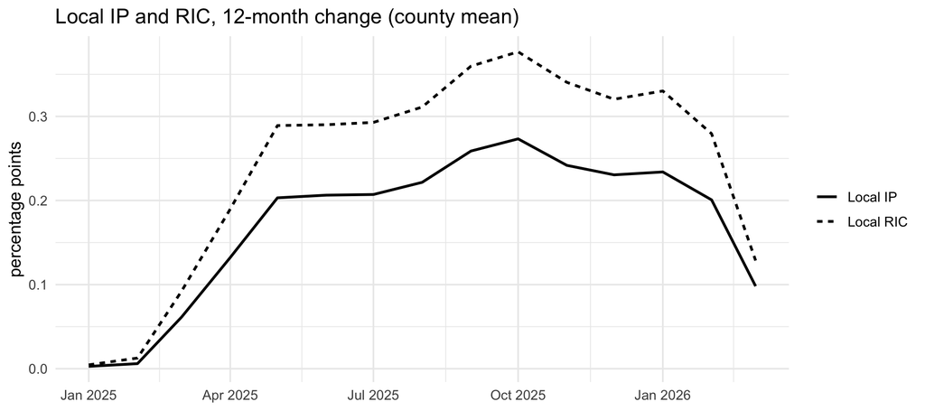

```r
ce12 <- copy(ce); setorder(ce12, fips, date)
ce12[, `:=`(IP12 = frollsum(dIP, 12), RIC12 = frollsum(dRIC, 12)), by = fips]
f12 <- ce12[!is.na(IP12), .(`Local IP` = mean(IP12), `Local RIC` = mean(RIC12)), by = date]
f12 <- melt(f12, id.vars = "date")
ggplot(f12, aes(date, value, linetype = variable)) + geom_line(linewidth = 0.9) +
  labs(title = "Local IP and RIC, 12-month change (county mean)", x = NULL, y = "percentage points", linetype = NULL) +
  theme_minimal(base_size = 12)
```

```r
ggsave(file.path(figd, "fig_local_ip_ric_12m.png"), width = 9, height = 4.5, dpi = 150)
```

# 5. Estimation panel

```r
laus <- fread(file.path(proc, "laus_county_unemployment.csv"),
              colClasses = list(character = c("fips", "state_fips")))
laus[, date := as.Date(date)]
setorder(laus, fips, date)
laus[, d12_u := unemp_rate - shift(unemp_rate, 12), by = fips]   # 12-month change (AT2026 outcome basis, in levels)

# complete date grid with zero shocks before the first customs month (tariffs flat before 2024)
grid_dates <- seq(as.Date("2023-01-01"), last_month, by = "month")
Z <- CJ(fips = unique(ce$fips), date = grid_dates)
Z <- merge(Z, ce, by = c("fips", "date"), all.x = TRUE)
Z[is.na(dIP), dIP := 0]; Z[is.na(dRIC), dRIC := 0]
setorder(Z, fips, date)

tag <- function(m) ifelse(m < 0, paste0("f", abs(m)), paste0("l", m))
for (m in -G:M) {
  Z[, paste0("IP_", tag(m))  := shift(dIP,  n = m, type = "lag"), by = fips]
  Z[, paste0("RIC_", tag(m)) := shift(dRIC, n = m, type = "lag"), by = fips]
}
ip_terms  <- paste0("IP_",  tag(-G:M))
ric_terms <- paste0("RIC_", tag(-G:M))

dat <- merge(Z[date >= est_start & date <= est_end], laus[, .(fips, date, unemp_rate, d12_u)], by = c("fips", "date"))
dat <- merge(dat, Nc, by.x = "fips", by.y = "fips")
dat[, `:=`(state = substr(fips, 1, 2), cal_month = month(date))]
cat(nrow(dat), "county-month rows;", uniqueN(dat$fips), "counties;",
    sum(is.na(dat$unemp_rate)), "rows with missing outcome (October 2025)\n")
```

```
## 75432 county-month rows; 3143 counties; 3143 rows with missing outcome (October 2025)
```

# 6. Distributed-lag event study

```r
run_dl <- function(y, fe, wt = NULL, data = dat) {
  fml <- as.formula(paste0(y, " ~ ", paste(c(ip_terms, ric_terms), collapse = " + "), " | ", fe))
  f <- feols(fml, data = data, cluster = ~state, weights = wt)
  dropped <- setdiff(c(ip_terms, ric_terms), names(coef(f)))
  if (length(dropped)) stop("Collinear terms dropped: ", paste(dropped, collapse = ", "),
                            ". Reduce G or M, or shorten the lag window.")
  f
}
fits <- list(
  "Baseline: county x month FE"          = run_dl("unemp_rate", "fips^cal_month + date"),
  "Employment-weighted"                  = run_dl("unemp_rate", "fips^cal_month + date", wt = ~N_c),
  "12-month-change outcome (AT2026)"     = run_dl("d12_u", "fips + date"))
etable(fits, keep = c("IP_f1", "IP_l0", "IP_l3", "RIC_f1", "RIC_l0", "RIC_l3"), fitstat = ~ n + r2)
```

|  |  | Baseline: coun.. | Employment-wei.. | 12-month-chang.. |
| --- | --- | --- | --- | --- |
| 1 | Dependent Var.: | unemp_rate | unemp_rate | d12_u |
| 2 |  |  |  |  |
| 3 | IP_f1 | 0.2283 (0.2562) | 0.3360 (0.2392) | 0.1721 (0.2887) |
| 4 | IP_l0 | -0.0417 (0.1898) | -0.0251 (0.3526) | -0.1419 (0.2647) |
| 5 | IP_l3 | 0.1602 (0.2322) | 0.1536 (0.5555) | 0.0408 (0.2754) |
| 6 | RIC_f1 | -0.2483 (0.5820) | -0.9037 (0.5971) | -0.2138 (0.6521) |
| 7 | RIC_l0 | -0.0874 (0.4273) | -0.1085 (0.7158) | 0.0937 (0.4849) |
| 8 | RIC_l3 | -0.7977 (0.5538) | -1.956 (1.301) | -0.3203 (0.6098) |
| 9 | Fixed-Effects: | ---------------- | ---------------- | ---------------- |
| 10 | fips-cal_month | Yes | Yes | No |

[output cut: 6 more lines]

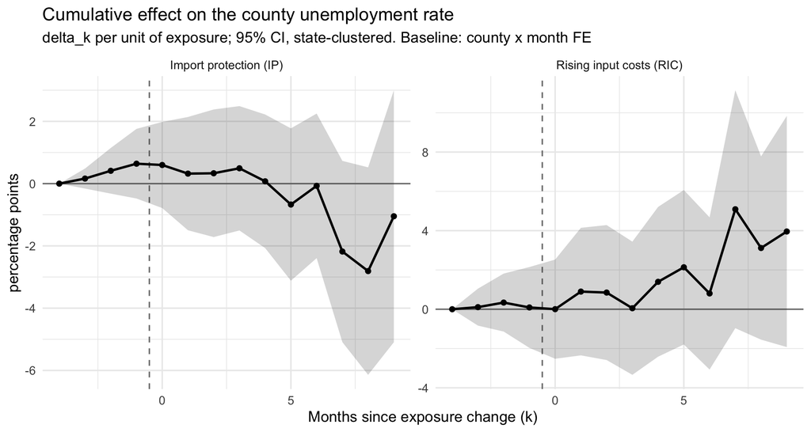

```r
cum_effects <- function(fit, prefix) {
  ms <- -G:M
  nm <- paste0(prefix, "_", tag(ms))
  b <- coef(fit)[nm]; V <- vcov(fit)[nm, nm]
  res <- rbindlist(lapply(seq_along(ms), function(j) {
    a <- as.numeric(seq_along(ms) <= j)
    data.table(k = ms[j], est = sum(a * b), se = sqrt(drop(t(a) %*% V %*% a)))
  }))
  rbind(data.table(k = -G - 1, est = 0, se = 0), res)         # delta_k = 0 for k < -G
}
cum <- rbindlist(lapply(names(fits), function(s)
  rbind(cum_effects(fits[[s]], "IP")[, exposure := "Import protection (IP)"],
        cum_effects(fits[[s]], "RIC")[, exposure := "Rising input costs (RIC)"])[, spec := s]))
cum[, `:=`(lo = est - 1.96 * se, hi = est + 1.96 * se)]

ggplot(cum[spec == names(fits)[1]], aes(k, est)) +
  geom_hline(yintercept = 0, colour = "grey50") +
  geom_vline(xintercept = -0.5, linetype = "dashed", colour = "grey50") +
  geom_ribbon(aes(ymin = lo, ymax = hi), alpha = 0.2) + geom_line(linewidth = 0.9) + geom_point(size = 1.6) +
  facet_wrap(~exposure, scales = "free_y") +
  labs(title = "Cumulative effect on the county unemployment rate",
       subtitle = "delta_k per unit of exposure; 95% CI, state-clustered. Baseline: county x month FE",
       x = "Months since exposure change (k)", y = "percentage points") +
  theme_minimal(base_size = 12)
```

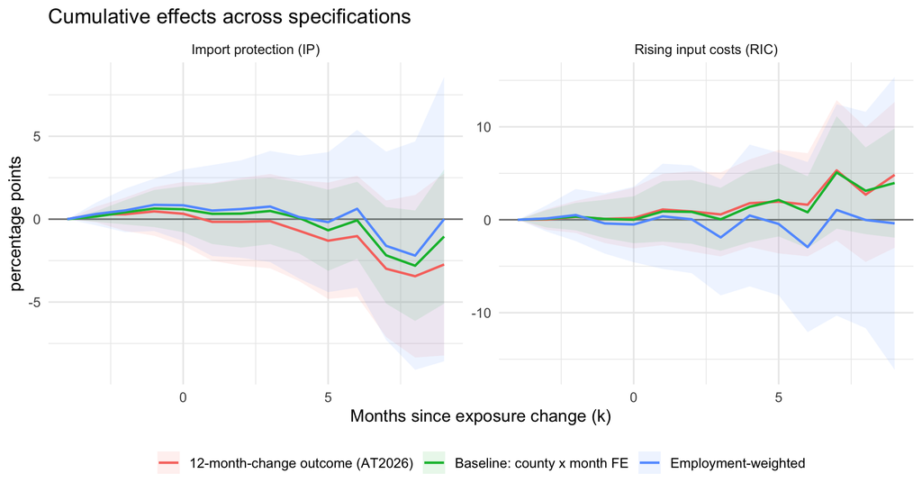

```r
ggsave(file.path(figd, "fig_cumulative_effects.png"), width = 9, height = 4.8, dpi = 150)

ggplot(cum, aes(k, est, colour = spec, fill = spec)) +
  geom_hline(yintercept = 0, colour = "grey50") +
  geom_ribbon(aes(ymin = lo, ymax = hi), alpha = 0.10, colour = NA) + geom_line(linewidth = 0.8) +
  facet_wrap(~exposure, scales = "free_y") +
  labs(title = "Cumulative effects across specifications", x = "Months since exposure change (k)",
       y = "percentage points", colour = NULL, fill = NULL) +
  theme_minimal(base_size = 12) + theme(legend.position = "bottom")
```

```r
ggsave(file.path(figd, "fig_cumulative_effects_specs.png"), width = 9, height = 5, dpi = 150)
```

## 6.1 Pre-trend tests

Joint Wald test that all lead coefficients are zero (equivalently $\delta_k=0$ for $-G\le k\le -1$).

```r
wald_leads <- function(fit, prefix) {
  nm <- paste0(prefix, "_f", G:1)
  b <- coef(fit)[nm]; V <- vcov(fit)[nm, nm]
  W <- drop(t(b) %*% solve(V) %*% b)
  data.table(chi2 = round(W, 2), df = length(nm), p_value = round(pchisq(W, length(nm), lower.tail = FALSE), 3))
}
pt <- rbindlist(lapply(names(fits), function(s)
  rbind(wald_leads(fits[[s]], "IP")[, exposure := "IP"], wald_leads(fits[[s]], "RIC")[, exposure := "RIC"])[, spec := s]))
pt[, .(spec, exposure, chi2, df, p_value)]
```

| spec | exposure | chi2 | df | p_value |
| --- | --- | --- | --- | --- |
| Baseline: county x month FE | IP | 1.30 | 3 | 0.730 |
| Baseline: county x month FE | RIC | 0.77 | 3 | 0.856 |
| Employment-weighted | IP | 2.54 | 3 | 0.469 |
| Employment-weighted | RIC | 2.95 | 3 | 0.399 |
| 12-month-change outcome (AT2026) | IP | 3.69 | 3 | 0.297 |
| 12-month-change outcome (AT2026) | RIC | 0.72 | 3 | 0.869 |

# 7. Counterfactual: no-tariff unemployment

The tariff contribution to unemployment is the post-change part of the fitted index,
$$\widehat{TE}_{c,t}=\sum_{m=0}^{M}\big(\hat\beta^{IP}_m\,\Delta
IP_{c,t-m}+\hat\beta^{RIC}_m\,\Delta RIC_{c,t-m}\big),$$
and the counterfactual (no-tariff) rate is $\hat u_{c,t}=u_{c,t}-\widehat{TE}_{c,t}$ (leads are excluded from $TE$: they test pre-trends and should not be treated as an effect).

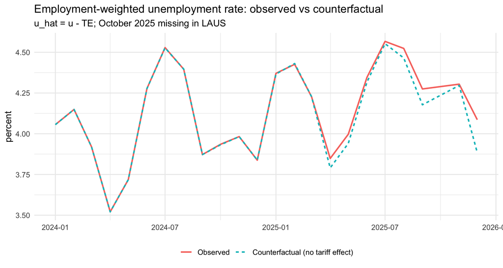

```r
fit0 <- fits[[1]]
cols_ip  <- paste0("IP_",  tag(0:M)); cols_ric <- paste0("RIC_", tag(0:M))
dat[, TE_IP  := drop(as.matrix(.SD) %*% coef(fit0)[cols_ip]),  .SDcols = cols_ip]
dat[, TE_RIC := drop(as.matrix(.SD) %*% coef(fit0)[cols_ric]), .SDcols = cols_ric]
dat[, `:=`(TE = TE_IP + TE_RIC, u_cf = unemp_rate - (TE_IP + TE_RIC))]

wtd <- function(x, w) sum(x * w, na.rm = TRUE) / sum(w[!is.na(x)])
nat <- dat[!is.na(unemp_rate), .(Observed = wtd(unemp_rate, N_c),
                                  `Counterfactual (no tariff effect)` = wtd(u_cf, N_c),
                                  TE = wtd(TE, N_c), TE_IP = wtd(TE_IP, N_c), TE_RIC = wtd(TE_RIC, N_c)), by = date]
natl <- melt(nat[, .(date, Observed, `Counterfactual (no tariff effect)`)], id.vars = "date")
ggplot(natl, aes(date, value, colour = variable, linetype = variable)) + geom_line(linewidth = 0.9) +
  labs(title = "Employment-weighted unemployment rate: observed vs counterfactual",
       subtitle = "u_hat = u - TE; October 2025 missing in LAUS", x = NULL, y = "percent", colour = NULL, linetype = NULL) +
  theme_minimal(base_size = 12) + theme(legend.position = "bottom")
```

```r
ggsave(file.path(figd, "fig_counterfactual_national.png"), width = 9, height = 4.8, dpi = 150)

nat[, .(date, TE = round(TE, 4), TE_IP = round(TE_IP, 4), TE_RIC = round(TE_RIC, 4))]
```

| date | TE | TE_IP | TE_RIC |
| --- | --- | --- | --- |
| 2024-01-01 | 0.0000 | 0.0000 | 0.0000 |
| 2024-02-01 | 0.0000 | 0.0000 | 0.0000 |
| 2024-03-01 | 0.0002 | 0.0000 | 0.0002 |
| 2024-04-01 | 0.0001 | 0.0000 | 0.0001 |
| 2024-05-01 | -0.0002 | 0.0000 | -0.0002 |
| 2024-06-01 | 0.0003 | -0.0001 | 0.0004 |
| 2024-07-01 | 0.0016 | -0.0003 | 0.0019 |
| 2024-08-01 | -0.0007 | 0.0002 | -0.0009 |
| 2024-09-01 | -0.0002 | 0.0002 | -0.0003 |
| 2024-10-01 | 0.0029 | -0.0013 | 0.0041 |

[output cut: 13 more lines]

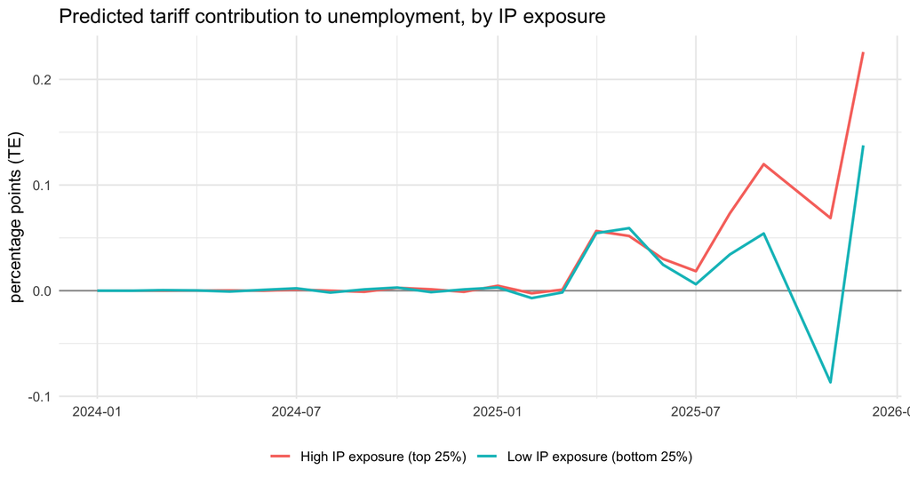

```r
# Quartiles of exposure: county average predicted IP contribution (employment-weighted cut-offs)
wq <- function(x, w, probs) { o <- order(x); cw <- cumsum(w[o]) / sum(w); x[o][vapply(probs, function(p) which(cw >= p)[1], 1L)] }
cty <- dat[, .(TE_IP_avg = mean(TE_IP), N_c = first(N_c)), by = fips]
cuts <- wq(cty$TE_IP_avg, cty$N_c, c(0.25, 0.75))
cty[, grp := fifelse(TE_IP_avg <= cuts[1], "Low IP exposure (bottom 25%)",
                     fifelse(TE_IP_avg >= cuts[2], "High IP exposure (top 25%)", NA_character_))]
byq <- merge(dat, cty[!is.na(grp), .(fips, grp)], by = "fips")[!is.na(unemp_rate),
              .(TE = wtd(TE, N_c), Observed = wtd(unemp_rate, N_c)), by = .(grp, date)]
ggplot(byq, aes(date, TE, colour = grp)) + geom_hline(yintercept = 0, colour = "grey60") +
  geom_line(linewidth = 0.9) +
  labs(title = "Predicted tariff contribution to unemployment, by IP exposure", x = NULL,
       y = "percentage points (TE)", colour = NULL) +
  theme_minimal(base_size = 12) + theme(legend.position = "bottom")
```

```r
ggsave(file.path(figd, "fig_te_by_ip_quartile.png"), width = 9, height = 4.8, dpi = 150)
```

# 8. Notes and limitations

- **Shock timing.** Customs data begin January 2024; tariff changes before February 2024 are set to zero. Outcomes end December 2025 so every lead has an observed shock.
- **October 2025.** LAUS county unemployment is missing for every county (federal shutdown); rows are dropped by the estimator.
- **Seasonality.** Baseline uses county x calendar-month FE; with about two observations per cell this is close to a year-over-year comparison and is compared against the 12-month-change specification above.
- **Suppression.** QCEW-suppressed industry cells enter as zero employment.
- **Unmapped industries.** Review the NAICS-3 -> BEA crosswalk in section 4 if employment is reported as unmapped.
- **Fixed-weight tariffs.** Pairs with no imports in month $t$ drop out and weights are renormalized; coverage is reported in section 2.
- **Not yet done:** trimming the top 1% of exposure, shift-share-robust standard errors, instrumenting realized with statutory exposure, and the 2023 base-year check.